# DeconstructedBeetlesCode

Laura Ospina-Rozo

16/02/2022

# Introduction

Libraries

```r
library(ggplot2)
library(wesanderson)
library(gridExtra)
library(rptR)
library(cowplot)
library(pavo)
library(tidyverse)
library(dplyr)
library(kableExtra)
library(graphics)
library(matrixStats)
```

Data Sets

```r
Reflect<-read.csv("../Data/1_HemisphericalReflectance.csv") %>%
  as.rspec(.) %>%
  procspec(.,fixneg = "zero")


Trans<-read.csv("../Data/2_Transmittance.csv") %>%
  filter (wl <= 1700 & wl >= 400) %>%
  as.rspec(.) %>%
  procspec(.,fixneg = "zero")


RefVis<-read.csv("../Data/3_ReflectanceVisModels.csv") %>%
  as.rspec(.) %>%
  procspec(.,fixneg = "zero") %>%
  aggspec(., by=4) %>%
  filter(wl <=700 & wl>=300)

Transmicro <- read.csv("../Data/4_TransmittanceMicroScale.csv")

Cylinders <- read.csv("../Data/4_XylonichusCylinderDiameters.csv")

Centroids <- read.csv("../Data/5_XylonichusCentroidDistance.csv")

QuasiOrder <-  read.csv("../Data/6_PrumModelResults.csv")

Ordered <-  read.csv("../Data/7_PhotonicCrystalModelResults.csv")
```

# Macro Scale

Comparison between the optical properties at a macro scale for the three beetles

```r
P_Prsi<-ggplot() +

  geom_ribbon(data=Trans,
              mapping = aes(x=wl,y=100-prsi3d,
                            ymin=100,ymax=100-prsi3d),
              fill="#b7b7b7", colour="black", alpha=0.5)+ # Transmittance

  geom_ribbon(data=Trans,
              mapping = aes(x=wl,y=100-prsi3d,
                            ymin=Reflect$prsi3,ymax=100-prsi3d),
              colour="black", fill="#2b8fff", alpha=0.5)+ # Absorbance

  geom_area(data=Reflect, aes(x=wl, y=prsi3),
            fill="#f8f813", colour="black", alpha=0.5) + # Reflectance

  scale_x_continuous(limits=c(400, 1700),
                     expand = c(0, 0))+
  scale_y_continuous(limits=c(0, 100), breaks = c(50,100),
                     expand = c(0, 0),
                     sec.axis = sec_axis(~100-.,breaks = c(100,50))) +
  theme_classic()+
  theme(axis.title.x = element_blank(),
        axis.text.x = element_text(color="white"))+
  theme(axis.text.y = element_text(size =18)) +
  ylab( " " )+
  theme(plot.margin = unit(c(0.6,0.4,0.1,0.4), "cm"))+
  geom_vline(xintercept = 700, linetype="dotted",
                color = "black", size=1)


P_Xyln<-ggplot() +

    geom_ribbon(data=Trans,
              mapping = aes(x=wl,y=100-xyln3d,
                            ymin=100,ymax=100-xyln3d),
              fill="#b7b7b7", colour="black", alpha=0.5)+ # Transmittance

    geom_ribbon(data=Trans,
              mapping = aes(x=wl,y=100-xyln3d,
                            ymin=Reflect$xyln3,ymax=100-xyln3d),
              colour="black", fill="#2b8fff", alpha=0.5)+ # Absorbance

  geom_area(data=Reflect, aes(x=wl, y=xyln3),
            fill="#f8f813", colour="black", alpha=0.5) + # Reflectance

  scale_x_continuous(limits=c(400, 1700),
                     expand = c(0, 0))+
  scale_y_continuous(limits=c(0, 100), breaks = c(50,100),
                     expand = c(0, 0),
                     sec.axis = sec_axis(~100-.,breaks = c(100,50))) +
  theme_classic()+
  theme(axis.title.x = element_blank(),
        axis.text.x = element_text(color="white"))+
  theme(axis.text.y = element_text(size =18)) +
  ylab( " " )+
  theme(plot.margin = unit(c(0.15,0.4,0.15,0.4), "cm"))+
  geom_vline(xintercept = 700, linetype="dotted",
                color = "black", size=1)


P_Ocul<-ggplot() +

  geom_ribbon(data=Trans,
              mapping = aes(x=wl,y=100-oliv2d,
                            ymin=100,ymax=100-oliv2d),
              fill="#b7b7b7", colour="black", alpha=0.5)+ # Transmittance

  geom_ribbon(data=Trans,
              mapping = aes(x=wl,y=100-oliv2d,
                            ymin=Reflect$oliv2,ymax=100-oliv2d),
              colour="black", fill="#2b8fff", alpha=0.5)+ # Absorbance

  geom_area(data=Reflect, aes(x=wl, y=oliv2),
            fill="#f8f813", colour="black", alpha=0.5) + # Reflectance

  scale_x_continuous(limits=c(400, 1700),
                     expand = c(0, 0))+
  scale_y_continuous(limits=c(0, 100), breaks = c(50,100),
                     expand = c(0, 0),
                     sec.axis = sec_axis(~100-.,breaks = c(100,50))) +
  theme_classic()+
  theme(axis.title.x = element_blank())+
  theme(axis.text.y = element_text(size =18)) +
  theme(axis.text.x = element_text(size =18)) +
  ylab( " " )+
  theme(plot.margin = unit(c(0.1,0.4,0.3,0.4), "cm"))+
  geom_vline(xintercept = 700, linetype="dotted",
                color = "black", size=1)
```

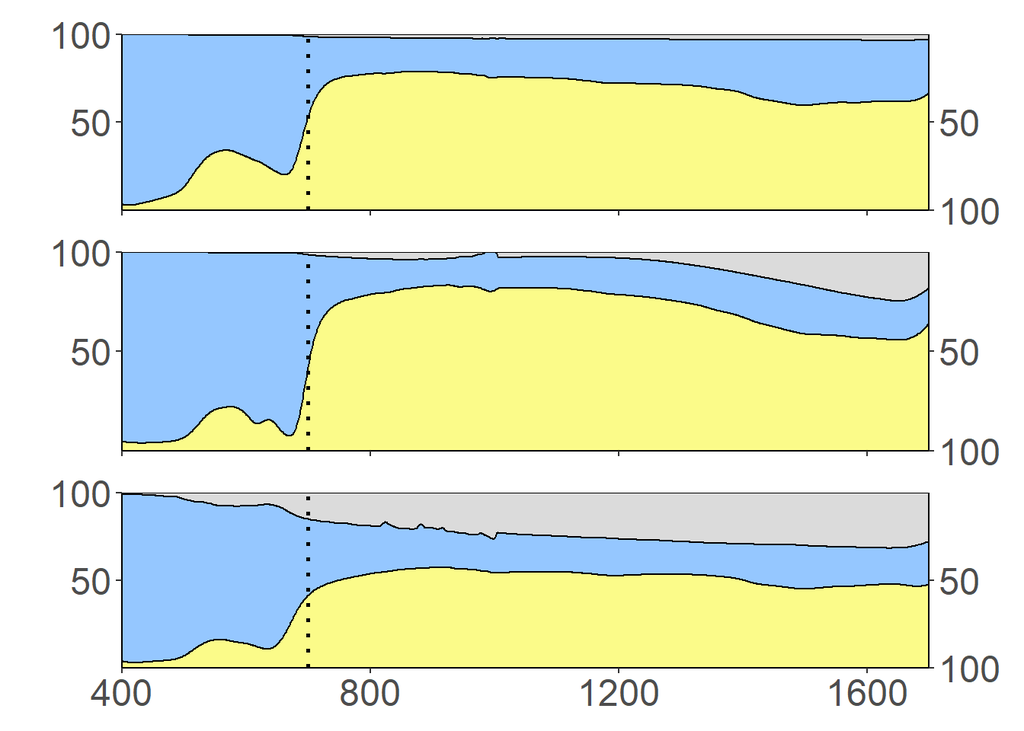

```r
# Align the three plots:
plot_grid(P_Prsi, P_Xyln, P_Ocul,
          align = "v", nrow=3, ncol=1, rel_widths = c(1, 1))
```

Yellow = Reflectance grey = Transmittance (inverted axis) blue = Absorbance

# Transmittance Scatterometer

The three beetles have very similar transmittance profile in their cuticle.

```r
# Prepare for plot
Transmicro<-
  Transmicro %>%
  mutate(across(spp, factor, levels=c("A.pras","X.euca","P.ocul")))
```

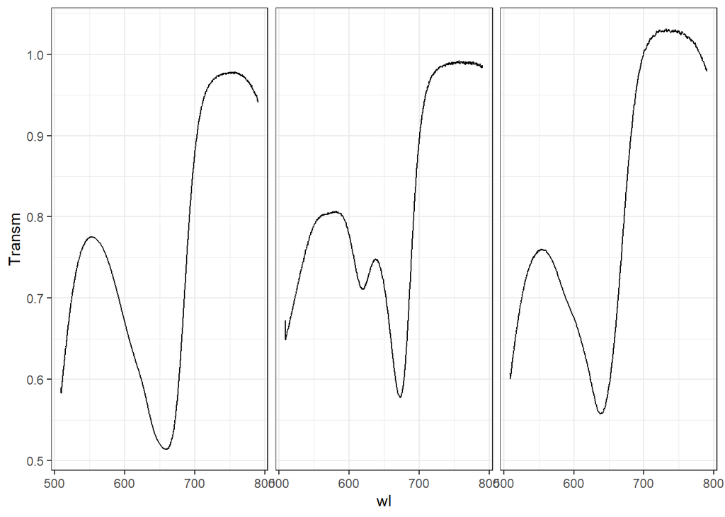

```r
# plot
ggplot(data=Transmicro, aes(wl,Transm,spp))+
  geom_line()+
  facet_wrap(~spp)+
  theme_bw()+
  theme(
    strip.background = element_blank(),
    strip.text.x = element_blank()
  )
```

# Statistical Descriptors

## Calculations

### Cylinder diameters

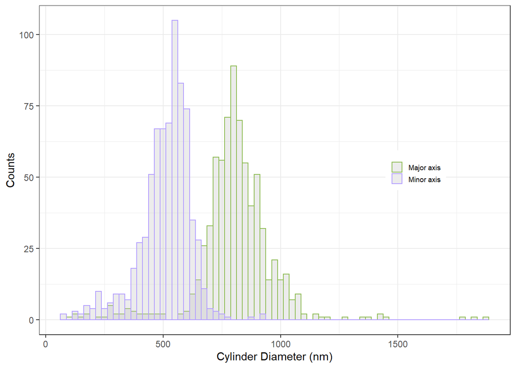

```r
Cylinders <-
  Cylinders %>%
  mutate(MajorAxisnm = MajorAxis * 1000, # from microns to nm
         MinorAxisnm = MinorAxis * 1000) # from microns to nm

# Prepare for the plot
HistAxis<-
  Cylinders %>%
  select (MajorAxisnm, MinorAxisnm ) %>%
  gather (Axis, Length)

# Plot
ggplot(HistAxis, aes(x=Length, fill=Axis, color=Axis))+
  geom_histogram(fill="gray", alpha=0.3,
                 position="identity", binwidth=25)+
  theme_bw()+
  theme(legend.position="top")+
  ylab("Counts")+
  xlab("Cylinder Diameter (nm)")+
  theme(legend.position = c(0.8,0.5))+
  theme(legend.title = element_blank())+
  theme(legend.text = element_text(size=7))+
  scale_color_manual(labels = c("Major axis", "Minor axis"),
                     values=c("#8dbb53", "#b39eff")) +
  theme(legend.key.size = unit(0.4, 'cm'))
```

### Centroid distances

The software provides the centroid distances as the x and y position in the image for each particle, in micrometers. To calculate the centre to centre distance, it is necesary to use the formula for euclidian distances

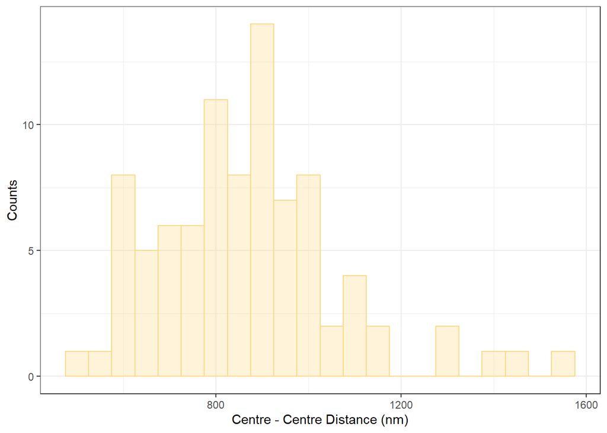

```r
Centroids <-
  Centroids %>%
  # Calculate euclidean distance:
  mutate(Euclidean = sqrt(((x1-x)^2)+((y2-y)^2))) %>%
  # convert from microns to nm
  mutate(Euclideannm = Euclidean * 1000)

# Plot:
ggplot(Centroids, aes(x=Euclideannm))+
  geom_histogram( color="#ffd781" ,fill="#ffd781", alpha=0.3,
                  position="identity",binwidth=50)+
  theme_bw()+
  theme(legend.position="top")+
  ylab("Counts")+
  xlab("Centre - Centre Distance (nm)")+
  theme(legend.position = c(0.8,0.5))+
  theme(legend.title = element_blank())+
  theme(legend.text = element_text(size=6))
```

### Circularity

This parameter indicates how circular are the particles. When the circularity is closer to 1, this means that the relationship between area and perimeter is close to 1, so the particle has a regular perimeter

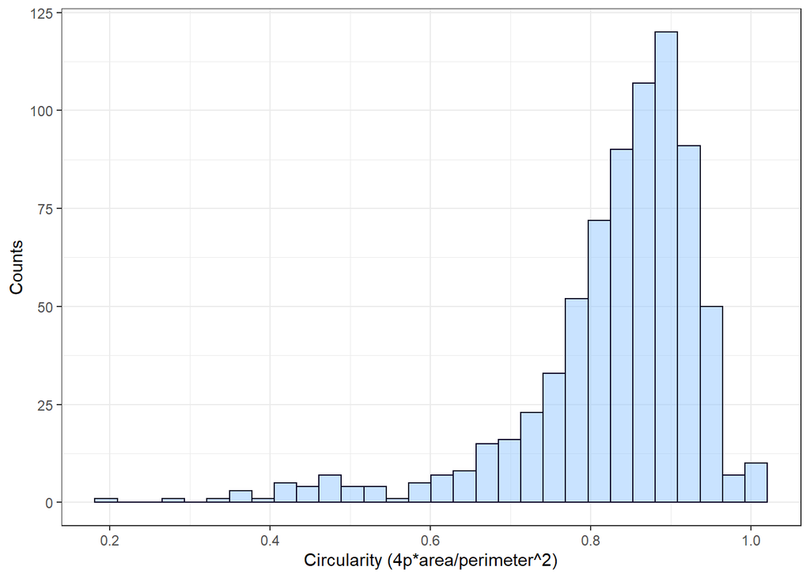

```r
# Plot:
ggplot(Cylinders, aes(x=circ.)) +
  geom_histogram( color="#0e0928" ,fill="#93c7ff", alpha=0.5,
                  position="identity")+
  theme_bw()+
  theme(legend.position="top")+
  ylab("Counts")+
  xlab("Circularity (4π*area/perimeter^2)")+
  scale_x_continuous(breaks=seq(0,1,0.2))+
  theme(legend.position = c(0.8,0.5))+
  theme(legend.title = element_blank())+
  theme(legend.text = element_text(size=6))
```

### Aspect ratio

Major Axis/minor Axis

If this value is far away from 1, it means that the elipse is flattened. if close to 1, it means that the ellipse is close to a circle.

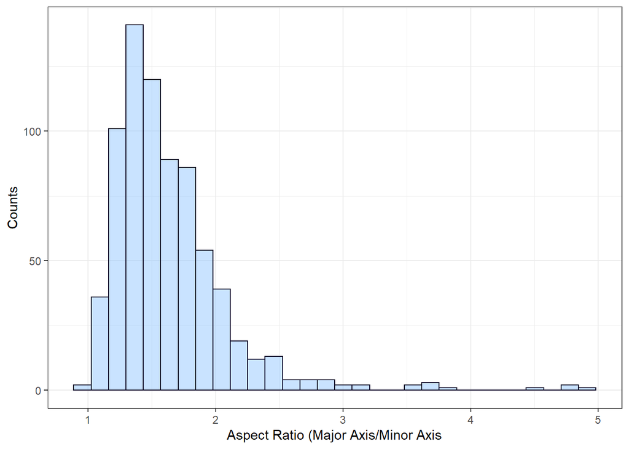

```r
# Plot:
ggplot(Cylinders, aes(x=AR)) +
  geom_histogram( color="#0e0928" ,fill="#93c7ff", alpha=0.5,
                  position="identity")+
  theme_bw()+
  theme(legend.position="top")+
  ylab("Counts")+
  xlab("Aspect Ratio (Major Axis/Minor Axis")+
  theme(legend.position = c(0.8,0.5))+
  theme(legend.title = element_blank())+
  theme(legend.text = element_text(size=6))
```

### Angle

This parameter indicates varies between 0-180 degrees, and it is the angle between the primary axis and a line parallel to the x-axis of the image.

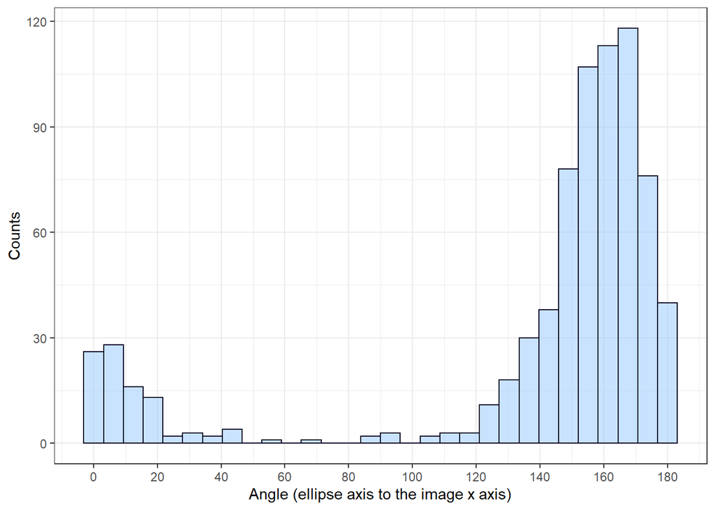

```r
# Plot:
ggplot(Cylinders, aes(x=angle)) +
  geom_histogram( color="#0e0928" ,fill="#93c7ff", alpha=0.5,
                  position="identity")+
  theme_bw()+
  theme(legend.position="top")+
  ylab("Counts")+
  xlab("Angle (ellipse axis to the image x axis)")+
  scale_x_continuous(breaks=seq(0,180,20))+
  theme(legend.position = c(0.8,0.5))+
  theme(legend.title = element_blank())+
  theme(legend.text = element_text(size=6))
```

### Correlations

We evaluated the correlation between the centre to centre distance and the diameter

First we need to create unique codes for the particles including the TEM number, the rectangle number and the ROI number.

In this way, we can combine the two data frames, cylinders diameter and centre to centre distance. Thus, for each particle we will obtain its diameter and its centre-to-centre distance to *one* of its adjacent particles.

```r
Cylinders2 <-
  Cylinders %>%
  unite("ROICode",c("section","rectangle","ROI")) %>%
  select(ROICode,MajorAxisnm,MinorAxisnm)

Centroids2 <-
  Centroids %>%
  mutate(label2 = substr(label,16,18)) %>%
  unite("ROICode",c("label2","ROI"),remove=FALSE) %>%
  unite("ROICompCode",c("label2","ROIcomp"),remove=FALSE) %>%
  select(ROICode,ROICompCode,Euclideannm) %>%
  # order:
  arrange(ROICompCode) %>%
  #remove particles that do not have diameter info:
  filter(ROICompCode!="1_4_17")

StructStats <-
  Cylinders2 %>%
  # select the ROIs for which we have the centroid distances:
  filter (ROICode  %in% (Centroids2$ROICompCode)) %>%
  # order:
  arrange(ROICode) %>%
  # Join data frames: cylinders with Centroids
  bind_cols(.,Centroids2) %>%
  select(-ROICode...1) %>%
  rename(AdjROI = ROICode...4) %>%
  select(4,1,2,3,5) %>%
  filter(MajorAxisnm<1400)

head(StructStats)
```

```
##   ROICompCode MajorAxisnm MinorAxisnm AdjROI Euclideannm
## 1      1_1_11         862         550 1_1_10    962.2333
## 2      1_1_14         765         592 1_1_10    719.4616
## 3      1_1_25         711         596 1_1_30    891.4034
## 4      1_1_27         732         560 1_1_30    610.0467
## 5      1_1_28         728         562 1_1_30    984.9152
## 6      1_1_29         782         521 1_1_30    921.2481
```

In this data frame, the first column is the label of the particles (i.e. transversal section of a cylinder in the white underlay of X. eucalypti) that we are studying. Second column and third column are the diameter. Since the particles are an ellipse, we kept the major and minor axis. Column 4 is the the label of a particle adjacent to the particle in column 1. Column 5 is the centre to centre distance between these two particles.

Now we can test if the diameter of the particle correlates to the centre to centre distance.

```r
cor.test(StructStats$MajorAxisnm,StructStats$Euclideannm)
```

```
##
##  Pearson's product-moment correlation
##
## data:  StructStats$MajorAxisnm and StructStats$Euclideannm
## t = 0.57344, df = 84, p-value = 0.5679
## alternative hypothesis: true correlation is not equal to 0
## 95 percent confidence interval:
##  -0.1514332  0.2707390
## sample estimates:
##        cor
## 0.06244572
```

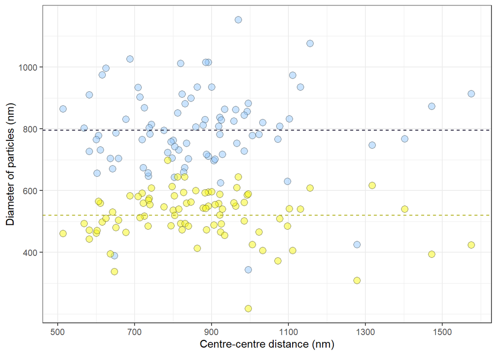

```r
ggplot(StructStats, aes(x = Euclideannm))+
  geom_point(aes(x = Euclideannm,y = MajorAxisnm),
             size=3, alpha=0.5,pch=21,
             col="black",fill="#93c7ff")+
  geom_point(aes(x = Euclideannm,y = MinorAxisnm),
             size=3, alpha=0.5,pch=21,
             col="black",fill="#f8f813")+
  theme_bw()+
  xlab("Centre-centre distance (nm)")+
  ylab("Diameter of particles (nm)")+
  scale_x_continuous(breaks=seq(500,1500,200))+
  scale_y_continuous(breaks=seq(400,1400,200))+
  geom_hline(yintercept=mean(StructStats$MajorAxisnm),
             linetype="dashed", color = "#0e0928")+
  geom_hline(yintercept=mean(StructStats$MinorAxisnm),
             linetype="dashed", color = "#abab0d")
```

Blue = major axis and yellow = minor axis

One last test, can the sum of the dimeter/2 of two adjacent particles explain its centre to centre distance?

```r
SubCylind <-
  Cylinders2 %>%
  filter (ROICode  %in% (StructStats$AdjROI))

StructStats$MajAxisAdj <- SubCylind$MajorAxisnm [factor(StructStats$AdjROI)]

StructStats$MinAxisAdj <- SubCylind$MinorAxisnm [factor(StructStats$AdjROI)]

StructStats <-
  StructStats %>%
  mutate(SumMajAxis = MajorAxisnm/2 + MajAxisAdj/2) %>%
  mutate(SumMinAxis = MinorAxisnm/2 + MinAxisAdj/2)
```

```r
ModEucAxis <- lm (StructStats$Euclideannm ~ StructStats$SumMajAxis + StructStats$SumMinAxis)

summary(ModEucAxis)
```

```
##
## Call:
## lm(formula = StructStats$Euclideannm ~ StructStats$SumMajAxis +
##     StructStats$SumMinAxis)
##
## Residuals:
##     Min      1Q  Median      3Q     Max
## -390.10 -131.58  -12.37   89.04  661.33
##
## Coefficients:
##                        Estimate Std. Error t value Pr(>|t|)
## (Intercept)            729.3293   271.7935   2.683  0.00879 **
## StructStats$SumMajAxis   0.2762     0.2300   1.201  0.23318
## StructStats$SumMinAxis  -0.1664     0.4076  -0.408  0.68412
## ---
## Signif. codes:  0 '***' 0.001 '**' 0.01 '*' 0.05 '.' 0.1 ' ' 1
##
## Residual standard error: 203 on 83 degrees of freedom
## Multiple R-squared:  0.01799,    Adjusted R-squared:  -0.005678
## F-statistic: 0.7601 on 2 and 83 DF,  p-value: 0.4709
```

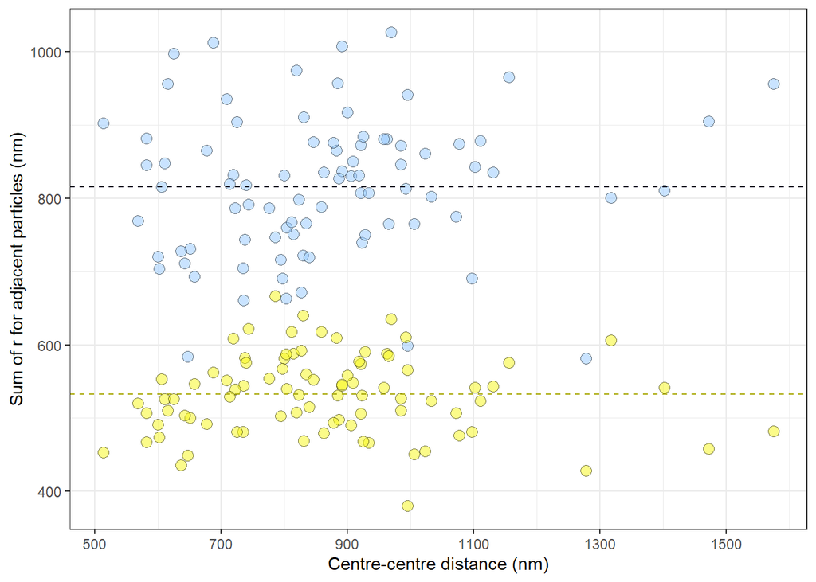

```r
ggplot(StructStats, aes(x = Euclideannm))+
  geom_point(aes(x = Euclideannm,y = SumMajAxis),
             size=3, alpha=0.5,pch=21,
             col="black",fill="#93c7ff")+
  geom_point(aes(x = Euclideannm,y = SumMinAxis),
             size=3, alpha=0.5,pch=21,
             col="black",fill="#f8f813")+
  theme_bw()+
  xlab("Centre-centre distance (nm)")+
  ylab("Sum of r for adjacent particles (nm)")+
  scale_x_continuous(breaks=seq(500,1500,200))+
  geom_hline(yintercept=mean(StructStats$SumMajAxis),
             linetype="dashed", color = "#0e0928")+
  geom_hline(yintercept=mean(StructStats$SumMinAxis),
             linetype="dashed", color = "#abab0d")
```

## Results

Table with the statistical descriptors of the cylinders in the Xylonichus white underlay structures

```r
maxA<- round(c(
mean(Cylinders$MajorAxisnm),
sd(Cylinders$MajorAxisnm),
quantile(Cylinders$MajorAxisnm, c(0.25,0.75)),
length(Cylinders$MajorAxisnm)),2)

minA <- round(c(
mean(Cylinders$MinorAxisnm),
sd(Cylinders$MinorAxisnm),
quantile(Cylinders$MinorAxisnm, c(0.25,0.75)),
length(Cylinders$MinorAxisnm)),2)

cent <- round(c(
mean(Centroids$Euclideannm),
sd(Centroids$Euclideannm),
quantile(Centroids$Euclideannm, c(0.25,0.75)),
length(Centroids$Euclideannm)),2)

Ecir <- round(c(
mean(Cylinders$circ.),
sd(Cylinders$circ.),
quantile(Cylinders$circ., c(0.25,0.75)),
length(Cylinders$circ.)),2)

ARat <- round(c(
mean(Cylinders$AR),
sd(Cylinders$AR),
quantile(Cylinders$AR, c(0.25,0.75)),
length(Cylinders$AR)),2)

# For the angles change the reference system
# Either the elypse is aligned with the horizontal
# Or it is aligned with the normal of the elytron
# angle should take values only between 0 and 90
Angs1 <- Cylinders$angle[Cylinders$angle<90] #less than 90
Angs2 <- 180-(Cylinders$angle[Cylinders$angle>90])# >90, invert
Angs3 <- c(Angs1,Angs2) # join them again
Angl <- round(c(
mean(Angs3),
sd(Angs3),
quantile(Angs3, c(0.25,0.75)),
length(Angs3)),2)
```

| Parameter | Mean | sd | 25% quantile | 75% quantile | n |
| --- | --- | --- | --- | --- | --- |
| Ellipse Major axis | 807.4 | 168.62 | 741.25 | 883 | 738 |
| Ellipse Minor axis | 510.87 | 109.37 | 462 | 581 | 738 |
| Aspect Ratio | 1.63 | 0.46 | 1.34 | 1.8 | 738 |
| Centre-Centre | 867.69 | 200.47 | 732.28 | 966.54 | 88 |
| Circularity | 0.83 | 0.11 | 0.79 | 0.9 | 738 |
| Angle | 20.85 | 14.86 | 10.04 | 29.06 | 737 |

- The particles are ellipses in which the aspect ratio is ~1.6 which means the major axis is ~1.6 times the minor axis.
- There is no correlation between the major/minor axis of the ellipses and the centre to centre distance. This is because the particles are not perfectly circular and the spacing between ellipses is determined by the chitin matrix (which varies considerably).
- The particles are often at angles. Their major axis can vary between 0 and 30 degrees from the horizontal of the image. This means that if we model the cross section of the cylinders as ellipses, the major axis of those ellipses will often align with the ventral surface of the elytron and almost never with the normal to the elytron.

## Procedure

This is a short description of the procedure I used to extract the centre to centre distance and the diameter of the transversal section of the cylinders from the TEM images

Here I refer as “particle” to the circle correspondent to a transversal section of a cylinder in the structure. Cylinders are filled with air and surrounded by a matrix of chitin.

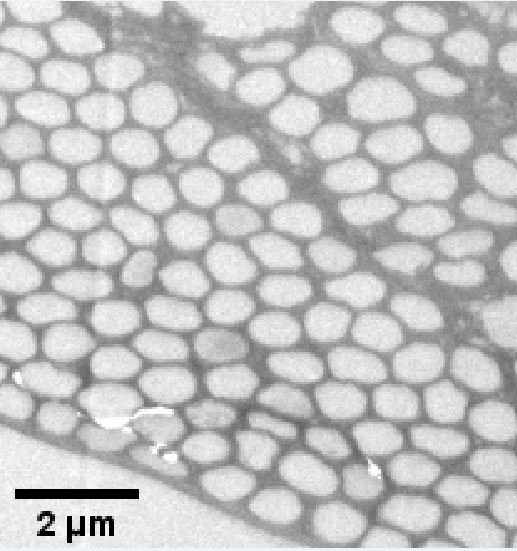

One rectangle of one TEM section

Then, we used the plugin Analyze particles in Image J to obtain statistical descriptors for the shapes of the transversal sections of the cylinders.

To do this we convert the image to black and white, then apply a threshold:

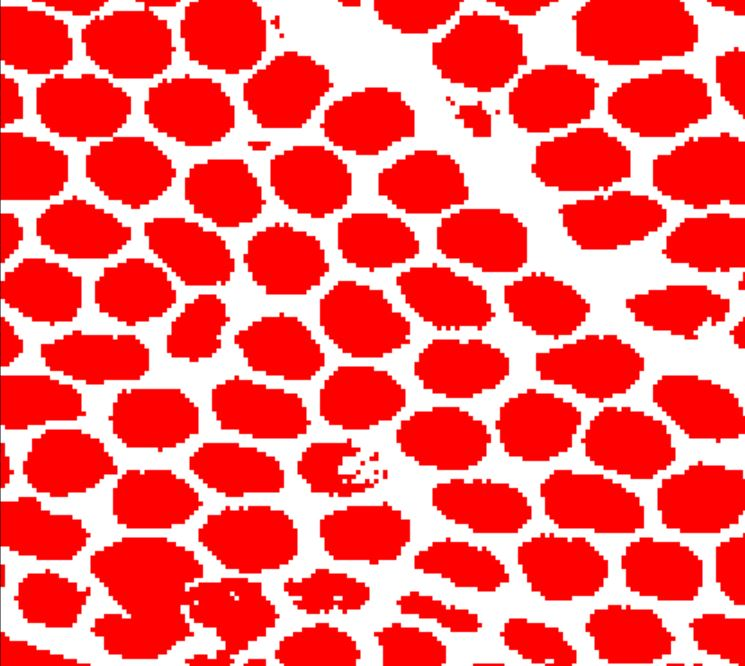

Example of a threshold to identify particles

Then, the plugin assigns a number to each particle, fits an ellipse to each particle and outputs the basic stats.

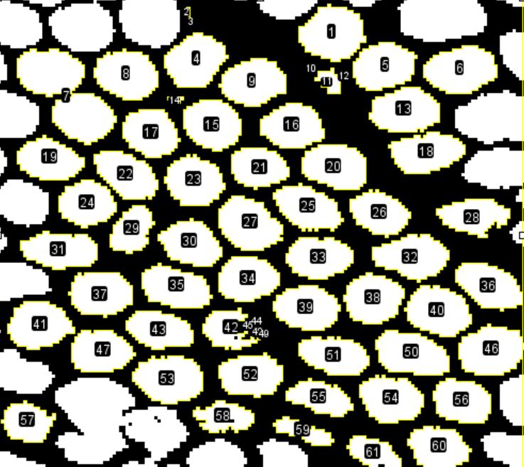

Example of the numbers assigned to each particle in the area (each particle is also refered as the region of interes, ROI)

Note: Although it is not shown here, the procedure also includes two extra steps to remove particles that are too small and probably just artifacts.

# Models

## Current

Photonic crystal

We are comparing models in which the cylinders transversal section is a circle of diameter 700, 820 and 1000 nm in two polariations: incident light polarized parallel (continuous) and perpendicular (dashed) to the cylinder axis

```r
OrderModel <-
  Ordered %>%
  gather (mod, Reflectance, -wl) %>%
  mutate (Polarization = substr(mod,1,7),
          Cylinder = substr(mod,8,13))

PolarizA <-
  OrderModel %>%
  filter (Polarization == "Perpen")

PolarizB <-
  OrderModel %>%
  filter (Polarization == "Parall")

LINES <- c("ParallP0700nm" = "solid",
           "ParallP0820nm" = "solid",
           "ParallP1000nm" = "solid",
           "PerpenP0700nm" = "dashed",
           "PerpenP0820nm" = "dashed",
           "PerpenP1000nm" = "dashed")


COLORS <- c("ParallP0700nm" = "#c4a922",
            "ParallP0820nm" = "black",
            "ParallP1000nm" = "grey",
            "PerpenP0700nm" = "#c4a922",
            "PerpenP0820nm" = "black",
            "PerpenP1000nm" = "grey")


M1P <- ggplot(OrderModel, aes(x=wl, y = Reflectance,
                       linetype = factor(mod), color=mod))+
  geom_line(size=0.8)+
  theme_bw() +
  scale_linetype_manual(values = LINES) +
  scale_color_manual(values = COLORS )+
  theme(legend.position="none")+
  xlab("Wavelength (nm)") +
  ylab("Reflectance (%)") +
  xlim(400,1700) +
  theme(axis.title.y = element_text(
    margin = margin(t = 0, r = 10, b = 0, l = 0)))
```

Quasi-ordered model

The plot shows the probability of reflectance of light inciding perpendicular to the cylinder axis

```r
PlotM1 <-
  QuasiOrder %>%
  mutate(., MeanS1 = rowMeans(select(., starts_with("Xyln1."))),
         ., MeanS2 = rowMeans(select(., starts_with("Xyln2."))),
         ., MeanS3 = rowMeans(select(., starts_with("Xyln3."))),
         ., MeanS4 = rowMeans(select(., starts_with("Xyln4."))),
         ., MeanS5 = rowMeans(select(., starts_with("Xyln5."))),
         ., MeanS6 = rowMeans(select(., starts_with("Xyln6."))),
         ., MeanS7 = rowMeans(select(., starts_with("Xyln7."))),
         ., MeanS8 = rowMeans(select(., starts_with("Xyln8."))),
         ., MeanS9 = rowMeans(select(., starts_with("Xyln9.")))) %>%
  select(wl,contains("Mean"))

PlotM1Means <-
  PlotM1 %>%
  mutate(Xyl.sd = rowSds(as.matrix(PlotM1[,2:10]))) %>%
  mutate(Xyl.mean = rowMeans2(as.matrix(PlotM1[,2:10]))) %>%
  select(wl,Xyl.sd,Xyl.mean)


M2P <- ggplot(PlotM1Means, aes(x=wl)) +
  geom_ribbon(aes(y = Xyl.mean*100,
                  ymin = Xyl.mean*100 - Xyl.sd*100,
                  ymax = Xyl.mean*100 + Xyl.sd*100,
                  fill = "#DCDCDC"), alpha = .4) +
    geom_line(aes(x=wl, y=Xyl.mean*100),
            size=1, colour="black")+
  scale_fill_manual(values=c("#DCDCDC"))+
  theme_bw() +
  ylab("Probablity of Reflectance x 100")+
  xlab("wavelength (nm)")+
  theme(legend.position="none")+
  xlim(400,1700) +
  theme(axis.title.y = element_text(
    margin = margin(t = 0, r = 10, b = 0, l = 0)))
```

Contrast between the two models

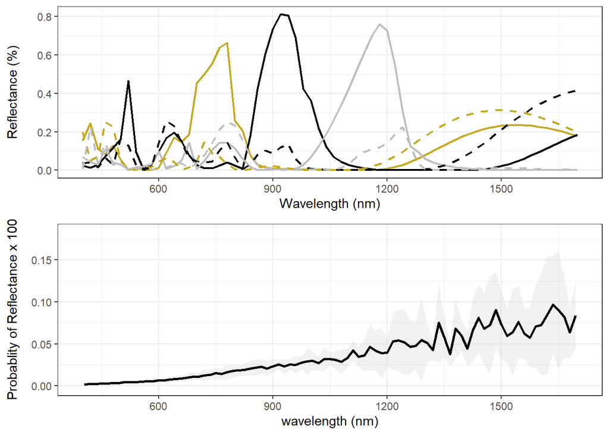

```r
plot_grid(M1P, M2P,
          align = "v", nrow=2, ncol=1, rel_widths = c(1, 1))
```